```python
# the following line is jupyter notebook specific
#%matplotlib inline
#%matplotlib notebook
```

http://matplotlib.org/gallery.html#

# Plotting Line Graphs

Let’s plot a simple line graph using `matplotlib`, and then customize it to create a more informative visualization of our data.

Just provide matplotlib with the numbers as shown below, and `matplotlib` should do the rest.

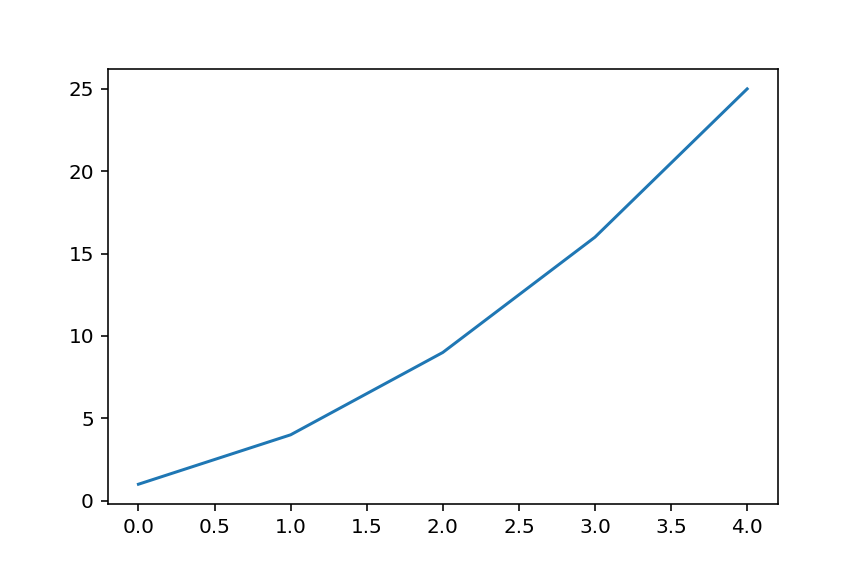

```python
import matplotlib.pyplot as plt
%matplotlib notebook

squares = [x ** 2 for x in range(1,6)]  # [1, 4, 9, 16, 25]
plt.plot(squares)
# in a program you would have to call plt.show()
```

We first import the `pyplot` module using the alias `plt` so we do not have to type `pyplot` repeatedly. `pyplot contains a number of functions that help generate charts and plots.

```
import matplotlib.pyplot as plt


squares = [x ** 2 for x in range(1,6)]  # [1, 4, 9, 16, 25]
plt.plot(squares)
plt.show()
```

## Changing the Label Type and Graph Thickness

Although the plot shown above illustrates that the numbers are increasing, the label type is too small and the line is too thin. Fortunately, `matplotlib` allows you to adjust every feature of a visualization.

The `linewidth` parameter of the `plot` function controls the thickness of the plotted line. The `title()` function sets a title for the chart. The fontsize parameters, which appear repeatedly throughout the code, control the size of the text on the chart. The `xlabel()` and `ylabel()` functions allow you to set a title for each of the axes, and the function `tick_params()` styles the tick marks. The arguments shown here affect the tick marks on both the x- and y-axes (`axes='both'`) and set the font size of the tick mark labels to 14 (`labelsize=14`).

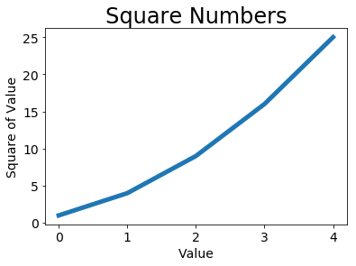

```python
import matplotlib.pyplot as plt

squares = [x ** 2 for x in range(1,6)]

plt.plot(squares, linewidth=5)
# Set chart title and label axes.
plt.title("Square Numbers", fontsize=24)
plt.xlabel("Value", fontsize=14)
plt.ylabel("Square of Value", fontsize=14)
# Set size of tick labels.
plt.tick_params(axis='both', labelsize=14)
```

## Correcting the Plot

Now, that we can read the chart better, we see that the data is not plotted correctly. Notice at the end of the graph that the square of 4.0 is shown as 25! Let’s fix that.

When you give plot() a sequence of numbers, it assumes the first data point corresponds to an x-coordinate value of `0`, but our first point corresponds to an x-value of 1. We can override the default behavior by giving plot() both the input and output values used to calculate the squares!

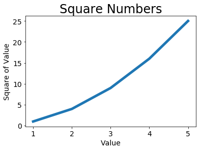

```python
import matplotlib.pyplot as plt


input_values = range(1,6)
squares = [x ** 2 for x in input_values]

plt.plot(input_values, squares, linewidth=5)

# Set chart title and label axes.
plt.title("Square Numbers", fontsize=24)
plt.xlabel("Value", fontsize=14)
plt.ylabel("Square of Value", fontsize=14)
# Set size of tick labels.
plt.tick_params(axis='both', labelsize=14)
```

# Plotting and Styling Discrete Points

A line plot is not necessarily the right visualization for discrete data point. Instead a plot of 'points', a scatter plot is more appropriate.

To plot a single point, use the `scatter()` function. Pass the single (x, y) values of the point of interest to `scatter()`.

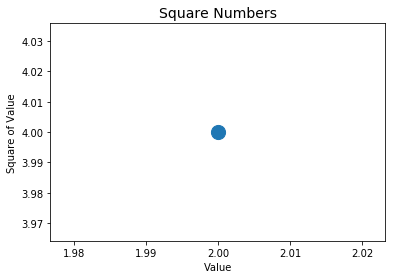

```python
import matplotlib.pyplot as plt

plt.scatter(2, 4, s=200)
# Set chart title and label axes.
plt.title("Square Numbers", fontsize=14)
plt.xlabel("Value", fontsize=10)
plt.ylabel("Square of Value", fontsize=10)
# Set size of tick labels.
plt.tick_params(axis='both', which='major', labelsize=10)
```

To plot a series of points, we can pass `scatter()` separate lists of x- and y-values. The `x_values` list contains the numbers to be squared, and `y_values` contains the square of each number. When these lists are passed to `scatter()`, matplotlib reads one value from each list as it plots each point. The points to be plotted are `(1, 1)`, `(2, 4)`, `(3, 9)`, `(4, 16)`, and `(5, 25)`.

```
Points to be plotted [(1, 1), (2, 4), (3, 9), (4, 16), (5, 25)]
```

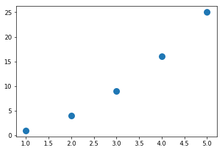

```python
import matplotlib.pyplot as plt

x_values = range(1, 6)
y_values = [x ** 2 for x in x_values]

print('Points to be plotted {}'.format(list(zip(x_values, y_values))))

plt.scatter(x_values, y_values, s=100)
```

#### Removing Outlines from Data Points

matplotlib lets you color points individually in a scatter plot. The default— blue dots with a black outline—works well for plots with a few points. But when plotting many points, the black outlines can blend together. To remove the outlines around points, pass the argument edgecolor='none' when you call scatter()

#### Defining Custom Colors

To change the color of the points, pass c to scatter() with the name of a color to use, as shown here:

```
plt.scatter(x_values, y_values, c='red', edgecolor='none', s=40)
```

```
plt.scatter(x_values, y_values, c=(0, 0, 0.8), edgecolor='none', s=40)
```

Values closer to 0 produce dark colors, and values closer to 1 produce lighter colors.

We pass the list of y-values to c and then tell pyplot which colormap to use through the cmap argument. This code colors the points with lower y-values light blue and the points with larger y-values dark blue.

```
[0, 1100, 0, 1100000]
```

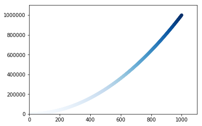

```python
import matplotlib.pyplot as plt

x_values = range(1, 1001)
y_values = [x ** 2 for x in x_values]

plt.scatter(x_values, y_values, c=y_values,
            cmap=plt.cm.Blues, edgecolor='none', s=40)
plt.axis([0, 1100, 0, 1100000])
```

# Saving Plots

If you want your program to save the plot to a file, call `plt.savefig()`:

```
plt.savefig('filename.png', bbox_inches='tight')
```

The first argument is a filename for the plot image, which will be saved in the same directory. The second argument trims extra whitespace from the plot. If you want the extra whitespace around the plot, you can omit this argument.

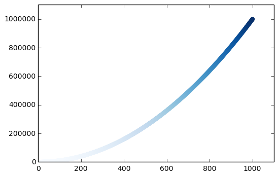

```python
import matplotlib.pyplot as plt

x_values = range(1, 1001)
y_values = [x ** 2 for x in x_values]

plt.scatter(x_values, y_values, c=y_values, cmap=plt.cm.Blues, edgecolor='none', s=40)
plt.axis([0, 1100, 0, 1100000])

plt.savefig('squares_plot.png', bbox_inches='tight')
```

```python
%%bash
ls -ltr squares_plot.png
```

```
-rw-r--r-- 1 vagrant vagrant 19222 Feb 24  2017 squares_plot.png
```

As you can see above, the file is generated and you can access it directly from the file server: http://127.0.0.1:8888/files/squares_plot.png

# Bar Plots

We are going to have a look at the data about citicens in Copenhagen. http://data.kk.dk/dataset/befolkningen-efter-ar-bydel-alder-og-statsborgerskab

In this section, we will mostly consider plotting histograms with bar plots. To do so, we have to first compute a bit of statistics. In the following we are computing how many people of a certain age lived in 2015 in Copenhagen.

```python
import kkdata


def get_population_stat():
    neighbourhoods = kkdata.STATISTICS[2015].keys()
    age_range = set([])
    for n in neighbourhoods:
        age_range.update(kkdata.STATISTICS[2015][n].keys())

    no_citicens_per_age = {}

    for n in neighbourhoods:
        for age in age_range:
            if age in kkdata.STATISTICS[2015][n].keys():
                c_codes = set(kkdata.STATISTICS[2015][n][age].keys())
                for f_code in c_codes:
                    no_citicens_per_age.setdefault(age, 0)
                    no_citicens_per_age[age] += kkdata.STATISTICS[2015][n][age][f_code]

    return no_citicens_per_age


ages = list(get_population_stat().keys())
no_citicens = list(get_population_stat().values())
get_population_stat()
```

```
{0: 8860,
 1: 7914,
 2: 7462,
 3: 7053,
 4: 6934,
 5: 6299,
 6: 6022,
 7: 5666,
 8: 5385,
 9: 4894,
 10: 4797,
 11: 4669,
 12: 4526,
 13: 4523,
 14: 4392,
```

[output cut: 92 more lines]

[figure not shown]

```python
%matplotlib notebook
import matplotlib.pyplot as plt


plt.bar(ages, no_citicens, width=0.5, linewidth=0, align='center')
plt.ticklabel_format(useOffset=False)
plt.axis([0, max(ages) + 10, 0, 17000])
title = 'Distribution of {} CPH Citizens in {}'.format(sum(no_citicens), 2015)
plt.title(title, fontsize=12)
plt.xlabel("Ages", fontsize=10)
plt.ylabel("Amount", fontsize=10)
plt.tick_params(axis='both', which='major', labelsize=10)
```

Now we are going to extend our function that computes the statistics, so that it can distinguish between Copenhagen citicens who are Danish nationals and those who are expats.

```python
import kkdata


def get_population_stat():
    neighbourhoods = kkdata.STATISTICS[2015].keys()
    age_range = set([])
    for n in neighbourhoods:
        age_range.update(kkdata.STATISTICS[2015][n].keys())

    no_danes_per_age = {}
    no_foreign_per_age = {}

    for n in neighbourhoods:
        for age in age_range:
            if age in kkdata.STATISTICS[2015][n].keys():
                c_codes = set(kkdata.STATISTICS[2015][n][age].keys())

                if 5100 in c_codes:
                    no_danes_per_age.setdefault(age, 0)
                    no_danes_per_age[age] += kkdata.STATISTICS[2015][n][age][5100]

                    c_codes.remove(5100)

                for f_code in c_codes:
                    no_foreign_per_age.setdefault(age, 0)
                    no_foreign_per_age[age] += kkdata.STATISTICS[2015][n][age][f_code]

    return no_danes_per_age, no_foreign_per_age

danes_per_age, foreigners_per_age = get_population_stat()

ages = list(danes_per_age.keys())
no_citicens = list(danes_per_age.values())
ages_f = list(foreigners_per_age.keys())
no_citicens_f = list(foreigners_per_age.values())
```

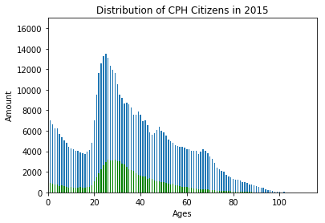

```python
import matplotlib.pyplot as plt


plt.bar(ages, no_citicens, width=0.5, linewidth=0, align='center')
plt.ticklabel_format(useOffset=False)
plt.axis([0, max(ages) + 10, 0, 17000])
title = 'Distribution of CPH Citizens in {}'.format(2015)
plt.title(title, fontsize=12)
plt.xlabel("Ages", fontsize=10)
plt.ylabel("Amount", fontsize=10)
plt.tick_params(axis='both', which='major', labelsize=10)


plt.bar(ages_f, no_citicens_f, width=0.5, linewidth=0, align='center',
        color='green')
plt.show()
```

The above plot allows us to get a feeling for the distribution of the corresponding groups with respect to each other. But it hides the total amount of citicens. For that we should stack the according values on to of each other.

To do that, we have to first harmonize the dimensions of our two populations.

```python
danes_per_age, foreigners_per_age = get_population_stat()

def add_keys_from_one_another(one, other):
    for k, v in one.items():
        if not k in other.keys():
            other[k] = 0

add_keys_from_one_another(danes_per_age, foreigners_per_age)
add_keys_from_one_another(foreigners_per_age, danes_per_age)

ages = list(danes_per_age.keys())
no_citicens = list(danes_per_age.values())

ages_f = list(foreigners_per_age.keys())
no_citicens_f = list(foreigners_per_age.values())
```

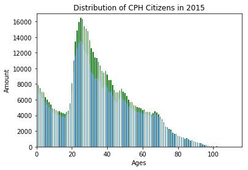

```python
plt.bar(ages, no_citicens, width=0.5, linewidth=0, align='center')
plt.ticklabel_format(useOffset=False)
plt.axis([0, max(ages) + 10, 0, 17000])
title = 'Distribution of CPH Citizens in {}'.format(2015)
plt.title(title, fontsize=12)
plt.xlabel("Ages", fontsize=10)
plt.ylabel("Amount", fontsize=10)
plt.tick_params(axis='both', which='major', labelsize=10)

plt.bar(ages_f, no_citicens_f, width=0.5, linewidth=0, align='center',
        color='green', bottom=no_citicens)
plt.show()
```

```python
import kkdata


def get_population_stat(year_of_interest=2015):
    neighbourhoods = kkdata.STATISTICS[year_of_interest].keys()
    age_range = set([])
    for n in neighbourhoods:
        age_range.update(kkdata.STATISTICS[year_of_interest][n].keys())

    no_danes_per_age = {}
    no_foreign_per_age = {}

    for n in neighbourhoods:
        for age in age_range:
            if age in kkdata.STATISTICS[year_of_interest][n].keys():
                c_codes = set(kkdata.STATISTICS[year_of_interest][n][age].keys())

                if 5100 in c_codes:
                    no_danes_per_age.setdefault(age, 0)
                    no_danes_per_age[age] += kkdata.STATISTICS[year_of_interest][n][age][5100]

                    c_codes.remove(5100)

                for f_code in c_codes:
                    no_foreign_per_age.setdefault(age, 0)
                    no_foreign_per_age[age] += kkdata.STATISTICS[year_of_interest][n][age][f_code]

    return no_danes_per_age, no_foreign_per_age
```

```python
year_of_interest = 1992
danes_per_age, foreigners_per_age = get_population_stat(year_of_interest)

add_keys_from_one_another(danes_per_age, foreigners_per_age)
add_keys_from_one_another(foreigners_per_age, danes_per_age)

ages = list(danes_per_age.keys())
no_citicens = list(danes_per_age.values())

ages_f = list(foreigners_per_age.keys())
no_citicens_f = list(foreigners_per_age.values())
```

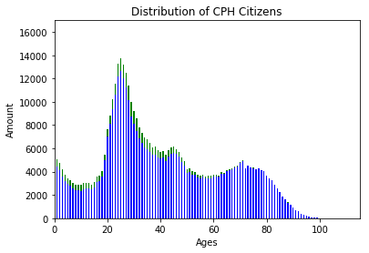

```python
def setup_plot():
    plt.ticklabel_format(useOffset=False)
    plt.axis([0, max(ages) + 10, 0, 17000])
    title = 'Distribution of CPH Citizens'
    plt.title(title, fontsize=12)
    plt.xlabel("Ages", fontsize=10)
    plt.ylabel("Amount", fontsize=10)
    plt.tick_params(axis='both', which='major', labelsize=10)


def plot_histogram(xs, ys, color='blue'):
    plt.bar(xs, ys, width=0.5, linewidth=0, align='center', color=color)

def plot_histogram_stack(xs, ys, ys_below, color='green'):
    plt.bar(xs, ys, width=0.5, linewidth=0, align='center', color=color,
            bottom=ys_below)


setup_plot()
plot_histogram(ages, no_citicens)
plot_histogram_stack(ages_f, no_citicens_f, no_citicens)

plt.show()
```

## Mind the Scale!

when visualizing your data keep in mind that you are responsible for how data is perceived. For example, people afraid of foreigners would understand from the following plot that there is an incredible increase of foreigners in the city. However, as you can see in the plot below, the increase of foreign citizens is not that big. Especially, it follows approxiately the development of the entire city population.

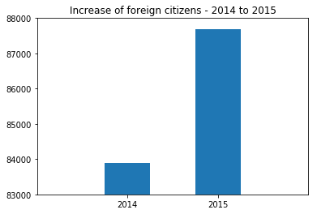

```python
years_of_interest = [2014, 2015]
_, foreigners_a = get_population_stat(years_of_interest[0])
_, foreigners_b = get_population_stat(years_of_interest[1])

y_values = [sum(foreigners_a.values()), sum(foreigners_b.values())]

plt.bar(years_of_interest, y_values, width=0.5, linewidth=0, align='center')
title = 'Increase of foreign citizens - {} to {}'.format(
    years_of_interest[0], years_of_interest[1])
plt.title(title, fontsize=12)
plt.ticklabel_format(useOffset=False)
plt.xticks(years_of_interest)
plt.ticklabel_format(useOffset=False)
plt.tick_params(axis='both', which='major', labelsize=10)
plt.axis([2013, 2016, 83000, 88000])

plt.show()
```

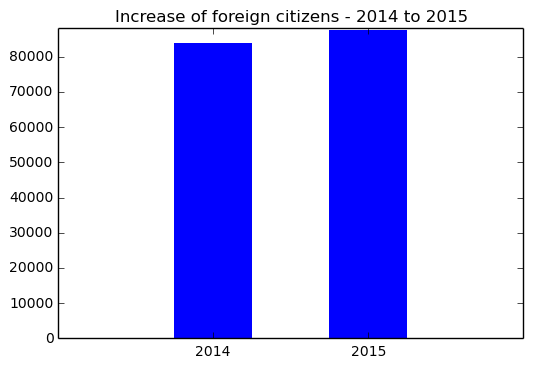

```python
plt.bar(years_of_interest, y_values, width=0.5, linewidth=0, align='center')
title = 'Increase of foreign citizens - {} to {}'.format(
    years_of_interest[0], years_of_interest[1])
plt.title(title, fontsize=12)
plt.ticklabel_format(useOffset=False)
plt.xticks(years_of_interest)
plt.ticklabel_format(useOffset=False)
plt.tick_params(axis='both', which='major', labelsize=10)
plt.axis([2013, 2016, 0, 88000])

plt.show()
```

# 3D Plots

Often, you need to access the third dimension to visualize your data properly. For example, in case you want to better understand the development of Copenhagen's population over time. In the following example, we plot 2D histograms 'behind' each other and make the plots a bit transparent.

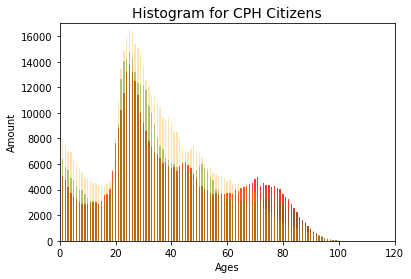

```python
def get_population_stat_complete(year_of_interest=2015):
    neighbourhoods = kkdata.STATISTICS[year_of_interest].keys()
    age_range = set([])
    for n in neighbourhoods:
        age_range.update(kkdata.STATISTICS[year_of_interest][n].keys())

    no_citicens_per_age = {}

    for n in neighbourhoods:
        for age in age_range:
            if age in kkdata.STATISTICS[year_of_interest][n].keys():
                c_codes = set(kkdata.STATISTICS[year_of_interest][n][age].keys())
                for f_code in c_codes:
                    no_citicens_per_age.setdefault(age, 0)
                    no_citicens_per_age[age] += kkdata.STATISTICS[year_of_interest][n][age][f_code]

    return (list(no_citicens_per_age.keys()),
            list(no_citicens_per_age.values()))


def plot_histogram(ages, amounts, year, color='blue', alpha=1.0):
    x_values, y_values = ages, amounts
    plt.bar(x_values, y_values, width=0.5, linewidth=0, align='center',
            color=color, alpha=alpha)
    plt.axis([0, 120, 0, 17000])
    title = 'Histogram for CPH Citizens'
    plt.title(title, fontsize=14)
    plt.xlabel("Ages", fontsize=10)
    plt.ylabel("Amount", fontsize=10)
    plt.tick_params(axis='both', which='major', labelsize=10)



year_of_interest = 1992
ages, amounts = get_population_stat_complete(year_of_interest)
plot_histogram(ages, amounts, year_of_interest, color='red', alpha=0.8)

year_of_interest = 1998
ages, amounts = get_population_stat_complete(year_of_interest)
plot_histogram(ages, amounts, year_of_interest, color='green', alpha=0.4)

year_of_interest = 2015
ages, amounts = get_population_stat_complete(year_of_interest)
plot_histogram(ages, amounts, year_of_interest, color='orange', alpha=0.3)
```

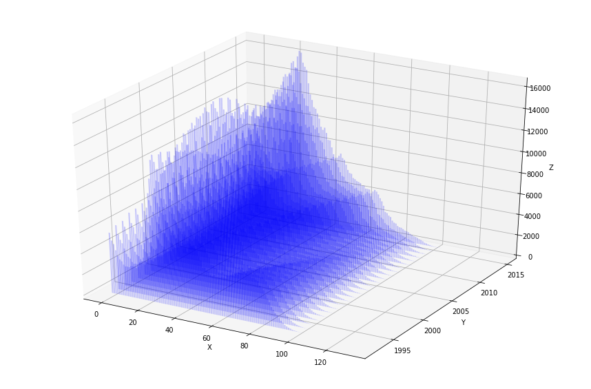

```python
from mpl_toolkits.mplot3d import Axes3D
import matplotlib.pyplot as plt


fig = plt.figure(figsize=(15,10))
ax = fig.add_subplot(111, projection='3d')
years = list(range(2015, 1991, -1))
for year_of_interest in years:
    ages, amounts = get_population_stat_complete(year_of_interest)
    xs, ys = ages, amounts
    ax.bar(xs, ys, zs=year_of_interest, zdir='y', alpha=0.2, color='b')

    #ax.scatter(xs, ys, zs=year_of_interest, zdir='y', alpha=0.2, cmap='hot', c=year_of_interest)
    #ax.plot_wireframe(xs, ys, year_of_interest, zdir='y', cstride=8, rstride=8, color = 'k')

ax.set_xlabel('X')
ax.set_ylabel('Y')
ax.set_zlabel('Z')

plt.savefig('3d_histo.png', bbox_inches='tight', dpi=300)
plt.show()
```

http://127.0.0.1:8888/files/3d_histo.png

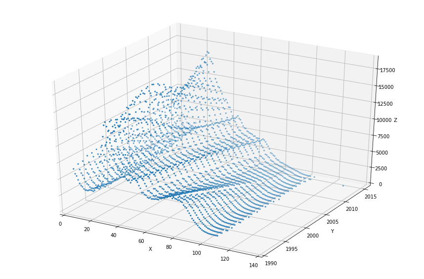

```python
from mpl_toolkits.mplot3d import Axes3D
import matplotlib.pyplot as plt
import numpy as np


#ax.plot3D?
fig = plt.figure(figsize=(15,10))
ax = fig.add_subplot(111, projection='3d')
years = list(range(2015, 1991, -1))

xs, ys, zs = [], [], []

for year_of_interest in years:
    ages, amounts = get_population_stat_complete(year_of_interest)
    #print(len(ages), len(amounts))
    y = [year_of_interest] * len(ages[:105])
    xs.append(ages[:105])
    ys.append(y)
    zs.append(amounts[:105])
#ax.scatter3D([[10,20], [10,25]], [[10,10], [15,15]], zs=[[15,5],[15,5]])
ax.scatter3D(xs, ys, zs=zs, s=5)
#ax.plot_wireframe(xs, ys, zs, rstride=10, cstride=10)


ax.set_xlabel('X')
ax.set_ylabel('Y')
ax.set_zlabel('Z')
ax.set_xlim3d(0, 140)
ax.set_ylim3d(1990, 2016)
ax.set_zlim3d(0, 19000)
# ax.view_init(0, 0)
plt.savefig('3d_histo2.png', bbox_inches='tight', dpi=300)
```

http://127.0.0.1:8888/files/3d_histo2.png

# Plotting with Pygal - Scalable Vector Graphics

In case you need plots in scalable vector graphics (SVG) you could make use of the PyGal library. If it is not installed on your virtual machine you can install it with (`pip install pygal`).

http://www.pygal.org/en/stable/index.html

```python
import pygal


danes_per_age, foreigners_per_age = get_population_stat(2015)

add_keys_from_one_another(danes_per_age, foreigners_per_age)
add_keys_from_one_another(foreigners_per_age, danes_per_age)

bar_chart = pygal.Bar()
bar_chart.add('Danish', danes_per_age.values())
bar_chart.add('Expat', foreigners_per_age.values())
bar_chart.render_to_file('bef_stat.svg')
```

http://127.0.0.1:8888/files/bef_stat.svg

```python
pie_chart = pygal.Pie()
pie_chart.title = 'Browser usage in February 2012 (in %)'
pie_chart.add('IE', 19.5)
pie_chart.add('Firefox', 36.6)
pie_chart.add('Chrome', 36.3)
pie_chart.add('Safari', 4.5)
pie_chart.add('Opera', 2.3)
pie_chart.render_to_file('./browser_usage.svg')
```

http://127.0.0.1:8888/files/browser_usage.svg

# Plotting to Maps with Folium

http://folium.readthedocs.io/en/latest/

```python
import json
import requests
import folium
import urllib

def get_city_location(city='Copenhagen'):
    #url_cph_center = "https://maps.googleapis.com/maps/api/geocode/json?address={}".format(city)
    #with urllib.request.urlopen(url_cph_center) as link:
    #    s = link.read()
    #    r = json.loads(s.decode('utf-8'))
    #results = r['results']

    url_cph_center = "https://maps.googleapis.com/maps/api/geocode/json"
    r = requests.get(url_cph_center, params={'sensor': 'false', 'address': city})
    results = r.json()['results']

    location = results[0]['geometry']['location']
    lat, lon = location['lat'], location['lng']
    #lat, lon = 55.676111, 12.568333
    return lat, lon


def get_geojson(url):
    response = requests.get(url)
    geo_json = response.json()
    return geo_json


cph_lat, cph_lon = get_city_location()
url_environ = 'http://wfs-kbhkort.kk.dk/k101/ows?service=WFS&version=1.0.0&request='\
              'GetFeature&typeName=k101:miljozone&outputFormat=json&SRSNAME=EPSG:4326'
geo_json = get_geojson(url_environ)

map_osm = folium.Map(location=(cph_lat, cph_lon), zoom_start=10)
folium.GeoJson(geo_json, name='geojson').add_to(map_osm)
map_osm.save('./osm.html')
map_osm
```

[interactive chart not shown]

http://127.0.0.1:8888/files/osm.html

```python
url_cph_center = 'https://maps.googleapis.com/maps/api/geocode/json'
r = requests.get(url_cph_center, params={'sensor': 'false', 'address': 'Copenhagen'})
r.json()
```

```
{'results': [{'address_components': [{'long_name': 'Copenhagen',
     'short_name': 'Copenhagen',
     'types': ['locality', 'political']},
    {'long_name': 'Denmark',
     'short_name': 'DK',
     'types': ['country', 'political']}],
   'formatted_address': 'Copenhagen, Denmark',
   'geometry': {'bounds': {'northeast': {'lat': 55.7270937, 'lng': 12.7342654},
     'southwest': {'lat': 55.615441, 'lng': 12.4533824}},
    'location': {'lat': 55.6760968, 'lng': 12.5683372},
    'location_type': 'APPROXIMATE',
    'viewport': {'northeast': {'lat': 55.7270937, 'lng': 12.7342654},
     'southwest': {'lat': 55.615441, 'lng': 12.4533824}}},
   'place_id': 'ChIJIz2AXDxTUkYRuGeU5t1-3QQ',
   'types': ['locality', 'political']}],
 'status': 'OK'}
```

```python
get_geojson(url_environ)
```

[output not shown]

[output cut: 721 more lines]

[output not shown]

```python
cph_lat, cph_lon = get_city_location()
url = 'http://wfs-kbhkort.kk.dk/k101/ows?service=WFS&version=1.0.0&' \
      'request=GetFeature&typeName=k101:storbyhaver&outputFormat=json&SRSNAME=EPSG:4326'
geo_json = get_geojson(url)

map_osm = folium.Map(location=(cph_lat, cph_lon), zoom_start=10)
folium.GeoJson(geo_json, name='geojson').add_to(map_osm)
map_osm.save('./osm2.html')
map_osm
```

[interactive chart not shown]

```python
get_geojson(url)
```

# Exercises!!!

1. Create visualizations comparing different groups of Copenhagen citizens. For example, how many French are there compared to Germans and how are they distributed over various neighbourhoods?
2. Add the markers that you get from the GeoJson response in the last example to the map.

   **Hint**: Make use of

   ```
   folium.Marker([12.578995447902946, 55.713167699503515],
    popup='Østerbro har fået en ny midlertidig urbanhave på' \
    ' bunkeren på Carl Nielsens Allé.'
    ).add_to(map_osm)
   ```

   and follow the documentation at http://folium.readthedocs.io/en/latest/quickstart.html